# Estudio socio-estadístico de la población española a lo largo del siglo XXI

Este trabajo se basa en un estudio socio-estadístico llevado a cabo en la población de España en el siglo XXI. El *objetivo* es ver la evolución del estilo de vida español con el paso del tiempo.  
En primer lugar se obtiene el dataset con los datos del estudio social realizado a la población.

Primero se cargan los paquetes necesarios:

```r
library(tidyr)
library(datos)
library(ggplot2)
library(dplyr)
library(lessR)
```

Una vez obtenida la lista de los paquetes necesarios, se carga y se realiza una estadística descriptiva del dataset:

```r
datos=encuesta
datos
```

```
## # A tibble: 21,483 × 9
##     anio estado_civil  edad raza  ingreso partido religion denominacion horas_tv
##    <int> <fct>        <int> <fct> <fct>   <fct>   <fct>    <fct>           <int>
##  1  2000 Nunca se ha…    26 Blan… 8000 -… Ind, p… Protest… Bautistas d…       12
##  2  2000 Divorciado      48 Blan… 8000 -… No fue… Protest… Bautista, n…       NA
##  3  2000 Viudo           67 Blan… No apl… Indepe… Protest… No denomina…        2
##  4  2000 Nunca se ha…    39 Blan… No apl… Ind, p… Cristia… No aplica           4
##  5  2000 Divorciado      25 Blan… No apl… No fue… Ninguna  No aplica           1
##  6  2000 Casado          25 Blan… 20000 … Fuerte… Protest… Bautistas d…       NA
##  7  2000 Nunca se ha…    36 Blan… 25000 … No fue… Cristia… No aplica           3
##  8  2000 Divorciado      44 Blan… 7000 -… Ind, p… Protest… Sínodo lute…       NA
##  9  2000 Casado          44 Blan… 25000 … No fue… Protest… Otra                0
## 10  2000 Casado          47 Blan… 25000 … Fuerte… Protest… Bautistas d…        3
## # ℹ 21,473 more rows
```

# 1. Estadística descriptiva

En primer lugar, es preciso conocer las dimensiones del conjunto de datos:

```r
dim(datos)
```

```
## [1] 21483     9
```

Nos encontramos con un dataset que consta de 21483 filas (número de personas utilizadas en la encuesta) y 9 columnas, éstas últimas correspondientes a las variables medidas en la población. Estas corresponden al año en que fue realizado el estudio, la edad de la persona, su estado civil, su ingreso anual, su religión, su ideología, su denominación así como el número de horas que dedica a ver la televisión. Dichas variables pueden observarse a continuación:

```r
names(datos)
```

```
## [1] "anio"         "estado_civil" "edad"         "raza"         "ingreso"
## [6] "partido"      "religion"     "denominacion" "horas_tv"
```

```r
clase=function(data){
for (i in colnames(data)){
  nombre=data[[i]]
  clase=class(nombre)
  print(clase)
}}

clase(datos)
```

```
## [1] "integer"
## [1] "factor"
## [1] "integer"
## [1] "factor"
## [1] "factor"
## [1] "factor"
## [1] "factor"
## [1] "factor"
## [1] "integer"
```

En dicho conjunto nos podemos encontrar con:

- Variables numéricas: *año*, *edad* y *horas_tv*.
- Variables categóricas nominales: *estado civil*, *raza*, *partido*, *religión* y *denominación*.
- Variables categóricas ordinales: *ingreso*.

Si se realiza un estudio de las mismas mediante una serie de estadísticos básicos como la media, la mediana y los cuartiles se obtiene lo siguiente:

```r
summary(datos)
```

```
##       anio                  estado_civil        edad              raza
##  Min.   :2000   Sin respuesta     :   17   Min.   :18.00   Otra     : 1959
##  1st Qu.:2002   Nunca se ha casado: 5416   1st Qu.:33.00   Negra    : 3129
##  Median :2006   Separado          :  743   Median :46.00   Blanca   :16395
##  Mean   :2007   Divorciado        : 3383   Mean   :47.18   No aplica:    0
##  3rd Qu.:2010   Viudo             : 1807   3rd Qu.:59.00
##  Max.   :2014   Casado            :10117   Max.   :89.00
##                                            NA's   :76
##                  ingreso                           partido
##  25000 o más         :7363   Independiente             :4119
##  No aplica           :7043   No fuertemente demócrata  :3690
##  20000 - 24999       :1283   Fuertemente demócrata     :3490
##  10000 - 14999       :1168   No fuertemente republicano:3032
##  15000 - 19999       :1048   Ind, pro dem              :2499
##  Se niega a responder: 975   Fuertemente republicano   :2314
##  (Other)             :2603   (Other)                   :2339
##         religion                      denominacion      horas_tv
##  Protestante:10846   No aplica              :10072   Min.   : 0.000
##  Católica   : 5124   Otra                   : 2534   1st Qu.: 1.000
##  Ninguna    : 3523   No denominacional      : 1683   Median : 2.000
##  Cristiana  :  689   Bautistas del sur      : 1536   Mean   : 2.981
##  Judía      :  388   Bautista, no sabe cuál : 1457   3rd Qu.: 4.000
##  Otra       :  224   Iglesia metodista unida: 1067   Max.   :24.000
##  (Other)    :  689   (Other)                : 3134   NA's   :10146
```

Este estudio se va a realizar mediante una separación por años. A continuación, se muestra el número de personas entrevistadas por año:

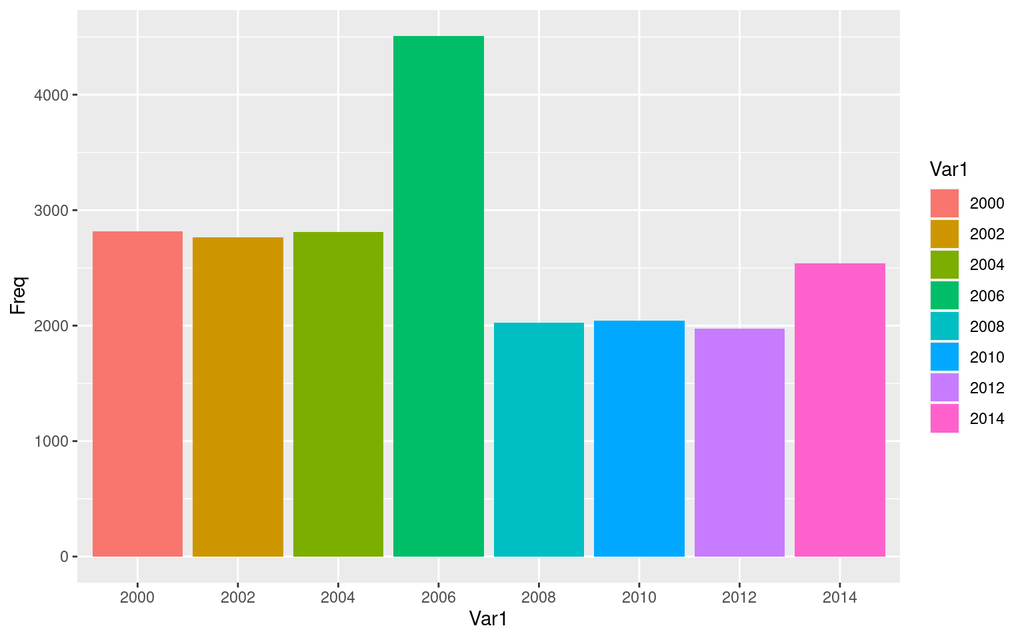

```r
tabla_años=table(datos$anio)
data=as.data.frame(tabla_años)
ggplot(data,aes(x=Var1,y=Freq,fill=Var1))+geom_bar(stat='identity')
```

La cantidad de datos recogidos a lo largo de los años es diferente. Desde el año 2000 al 2004, la cantidad de personas entrevistadas fue muy similar (en torno a 2800), seguidamente 2006 fue el año que más personas entrevistadas tuvo con 4510 personas. Seguidamente los años 2008, 2010 y 2012 tuvieron cifras de personas entrevistadas muy paecidas (en torno a los 2000). El último año en que tuvo lugar las entrevistas, el 2014, sufrió un repunte de candidatos entrevistados con 2538.

# Estudio de la evolución del estado civil en en siglo XXI

```r
tabla_estcivil=table(datos$estado_civil,datos$anio)
tabla_estcivil
```

```
##
##                      2000 2002 2004 2006 2008 2010 2012 2014
##   Sin respuesta         1    0    0    6    5    1    0    4
##   Nunca se ha casado  712  708  619 1080  531  565  526  675
##   Separado            112   96   95  156   70   65   68   81
##   Divorciado          441  445  415  732  281  341  317  411
##   Viudo               273  247  204  366  164  181  163  209
##   Casado             1278 1269 1479 2170  972  891  900 1158
```

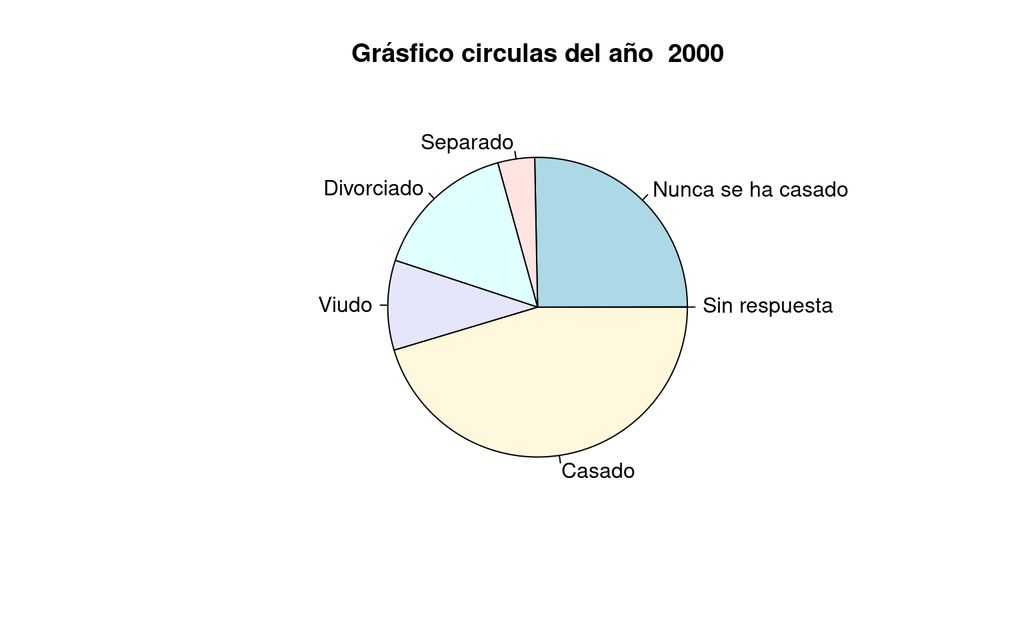

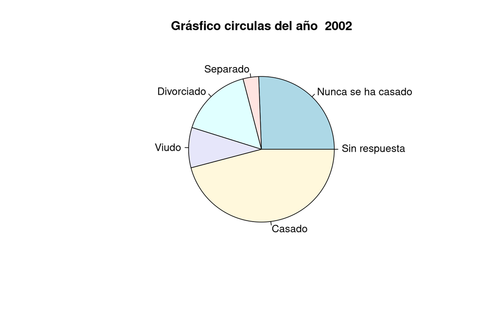

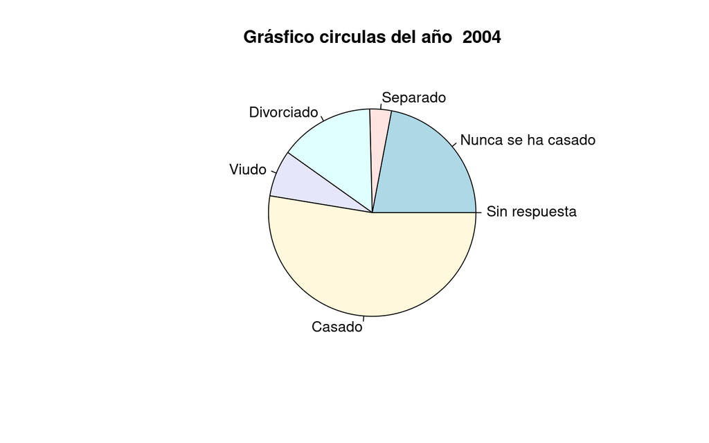

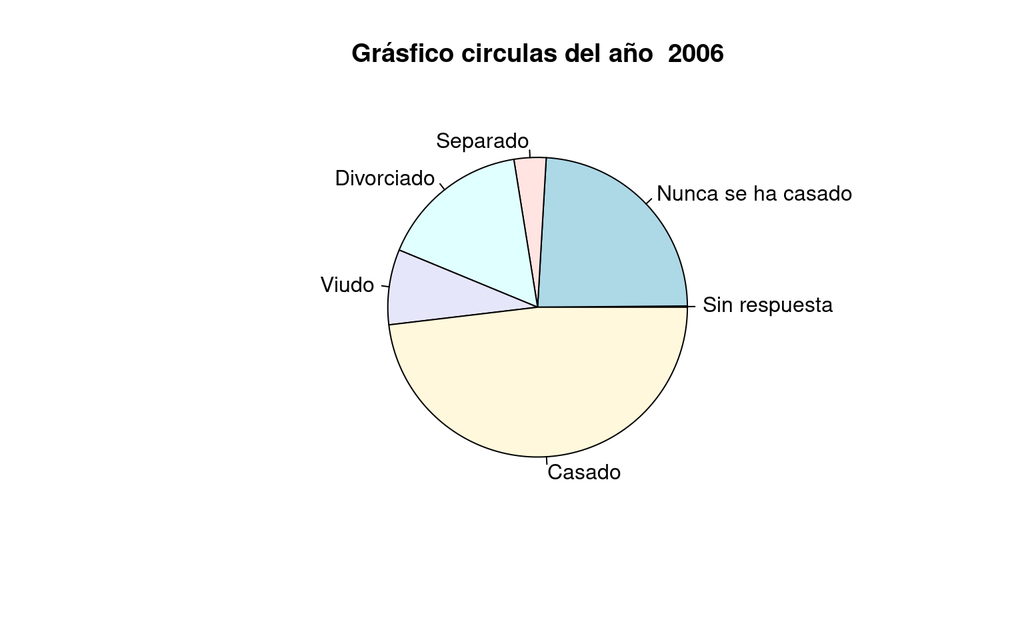

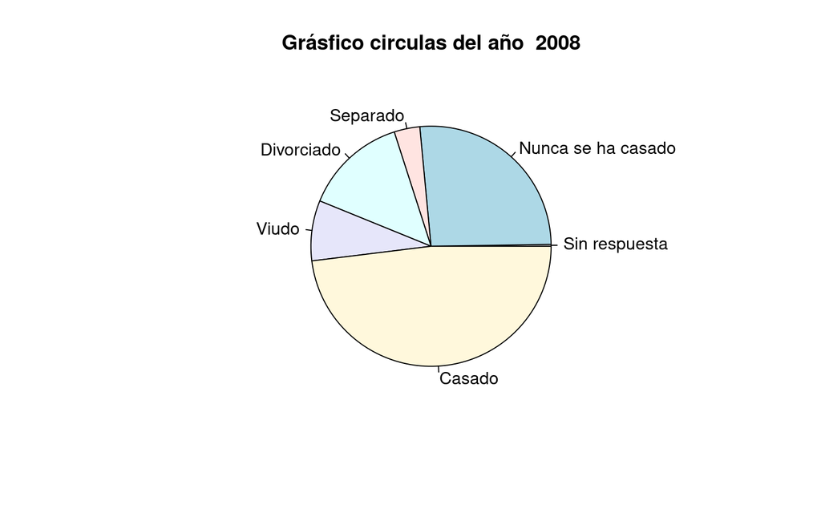

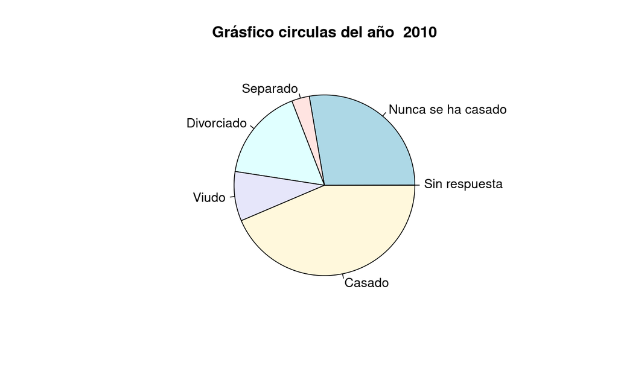

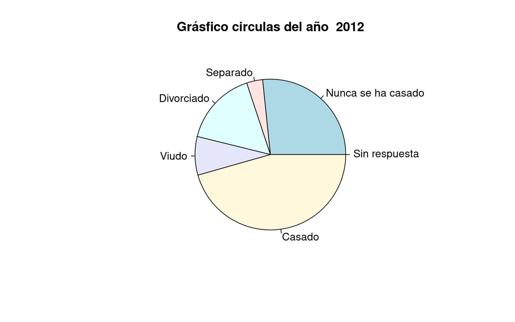

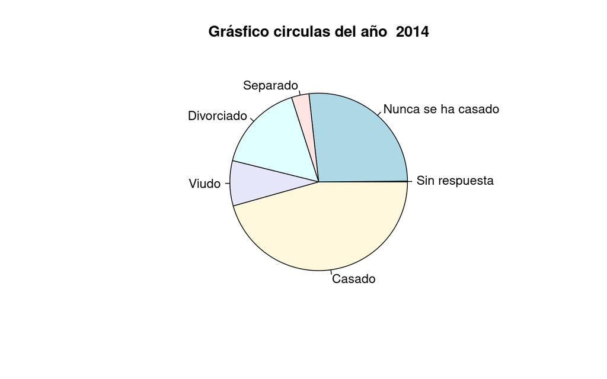

```r
  for(i in 1:ncol(tabla_estcivil)){
    cifras=tabla_estcivil[,i]
    año=1998+(i*2)
    cadena="Grásfico circulas del año "
    grafico= pie(cifras,main=paste(cadena,año))
    print(grafico)
  }
```